# Experiment on variable selection in multicollinearity

박찬우

#### **다중공선성하의 변수선택 시뮬레이션을 아래와 같이 시행**

1. 품질변수와 가격변수간에 상관관계가 있는 판매량 모형에서 품질변수 선택이 미치는 영향 확인
2. 품질변수와 가격변수간에 상관관계를 제거한 판매량 모형에서 품질변수 선택이 미치는 영향 확인

##### **품질변수와 가격변수간에 상관관계가 있는 판매량 모형에서 품질변수 선택이 미치는 영향 확인**

품질변수와 가격변수 생성에 있어 u2변수를 동일하게 사용하여 상관관계를 부여

```r
set.seed(70112)
n = 5000  # number of observation
trueB = c(3,-3, 3, 1.5, 0.7)
err = rnorm(n,sd=3)  # error term simulation

u1 = runif(n)
u2 = runif(n)
u3 = runif(n)
u4 = runif(n)

logPr = u1 +  u2
quality = u3 + u2
dummy1 = (u4> 0.7)*1.0
dummy2 = ((u4<0.7)&(u4>0.3))*1.0

logQ= trueB[1] + trueB[2]*logPr + trueB[3]*quality + trueB[4]*dummy1 + trueB[5]*dummy2 + err

sales = data.frame(logQ, logPr, quality, dummy1, dummy2)
head(sales)
```

```
##        logQ     logPr   quality dummy1 dummy2
## 1  7.070329 0.4902785 1.2965337      0      0
## 2  4.266556 0.2284658 0.5664445      0      1
## 3  7.190162 1.1619136 1.2292719      1      0
## 4  7.460651 1.0399048 1.6813053      0      1
## 5 -2.290508 1.6177827 0.6813804      0      0
## 6  4.515586 1.6936411 1.7407991      0      0
```

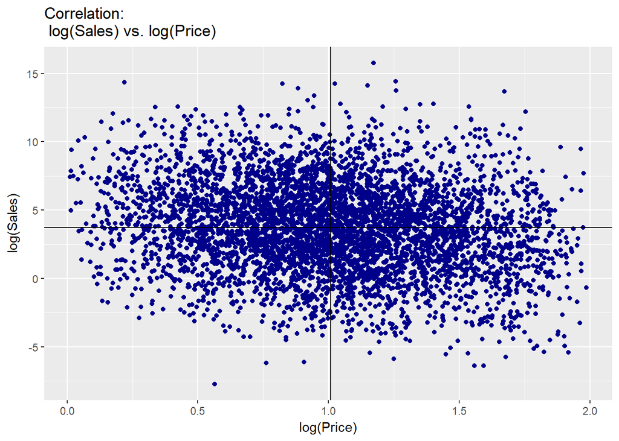

```r
library(ggplot2)

ggplot(data = sales, aes(x = logPr, y = logQ))+
  geom_point(col = 'dark blue') +
  geom_hline(yintercept = mean(logQ)) +
  geom_vline(xintercept = mean(logPr)) +
  ggtitle("Correlation: \n log(Sales) vs. log(Price)") +
  xlab("log(Price)") + ylab('log(Sales)')
```

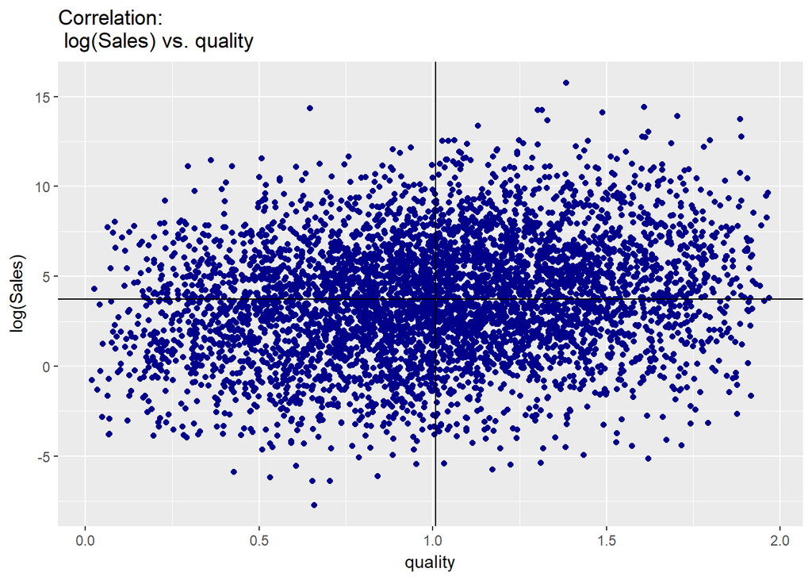

```r
ggplot(data = sales, aes(x = quality, y = logQ))+
  geom_point(col = 'dark blue') +
  geom_hline(yintercept = mean(logQ)) +
  geom_vline(xintercept = mean(quality)) +
  ggtitle("Correlation: \n log(Sales) vs. quality") +
  xlab("quality") + ylab('log(Sales)')
```

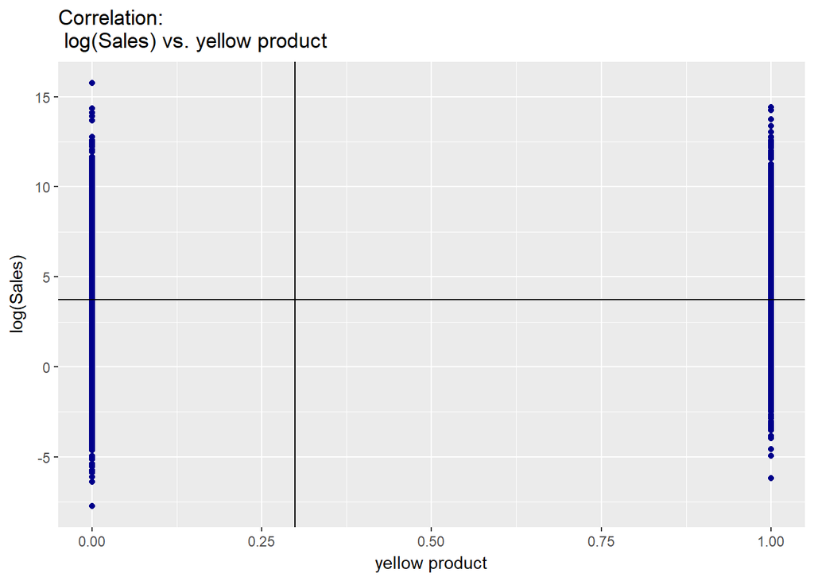

```r
ggplot(data = sales, aes(x = dummy1, y = logQ))+
  geom_point(col = 'dark blue') +
  geom_hline(yintercept = mean(logQ)) +
  geom_vline(xintercept = mean(dummy1)) +
  ggtitle("Correlation: \n log(Sales) vs. yellow product") +
  xlab("yellow product") + ylab('log(Sales)')
```

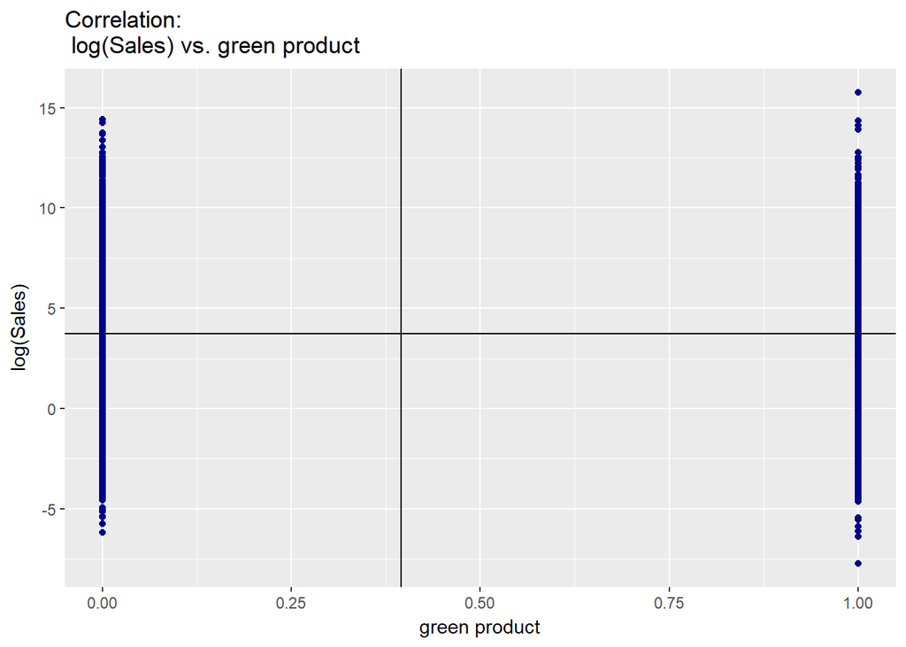

```r
ggplot(data = sales, aes(x = dummy2, y = logQ))+
  geom_point(col = 'dark blue') +
  geom_hline(yintercept = mean(logQ)) +
  geom_vline(xintercept = mean(dummy2)) +
  ggtitle("Correlation: \n log(Sales) vs. green product") +
  xlab("green product") + ylab('log(Sales)')
```

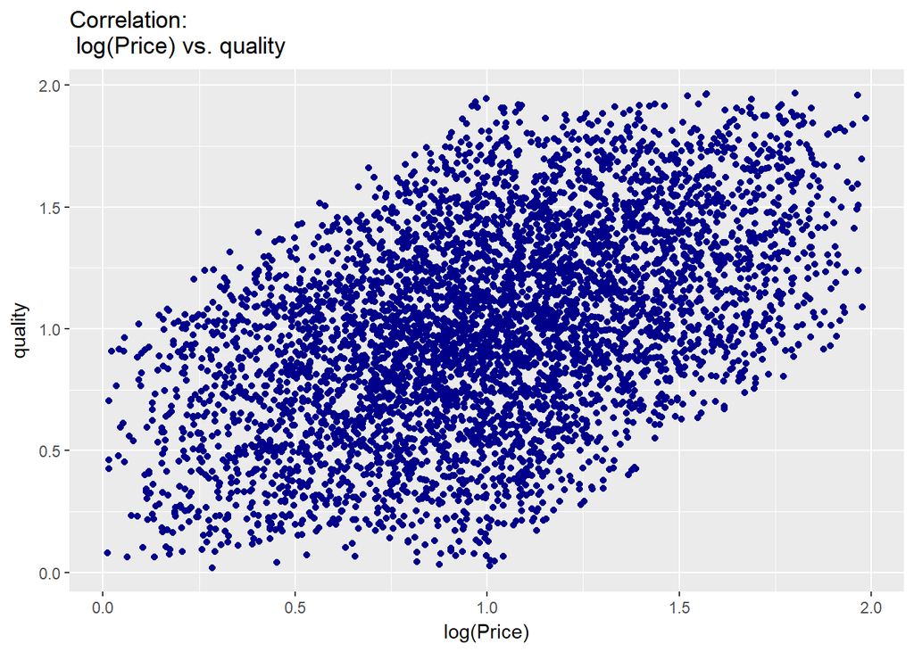

```r
ggplot(data = sales, aes(x = logPr, y = quality))+
  geom_point(col = 'dark blue') +
  ggtitle("Correlation: \n log(Price) vs. quality") +
  xlab("log(Price)") + ylab('quality')
```

```r
summary(lm(logQ~., data = sales))
```

```
##
## Call:
## lm(formula = logQ ~ ., data = sales)
##
## Residuals:
##      Min       1Q   Median       3Q      Max
## -11.6674  -2.0522   0.0407   2.0413  11.5772
##
## Coefficients:
##             Estimate Std. Error t value Pr(>|t|)
## (Intercept)   3.0681     0.1435  21.375  < 2e-16 ***
## logPr        -2.9805     0.1204 -24.747  < 2e-16 ***
## quality       3.0310     0.1187  25.541  < 2e-16 ***
## dummy1        1.2683     0.1092  11.614  < 2e-16 ***
## dummy2        0.5505     0.1022   5.386 7.52e-08 ***
## ---
## Signif. codes:  0 '***' 0.001 '**' 0.01 '*' 0.05 '.' 0.1 ' ' 1
##
## Residual standard error: 3.001 on 4995 degrees of freedom
## Multiple R-squared:  0.1652, Adjusted R-squared:  0.1645
## F-statistic: 247.1 on 4 and 4995 DF,  p-value: < 2.2e-16
```

- 분석 결과 모델 및 베타값은 상당히 유효하게 나타남
- 베타 값도 실제 모델 값과 1~2s.e. 정도의 오차만을 보임  
  (수업때와는 달리 관측값도 5,000개나 되다보니 상당히 유의한 결과를 도출)

```r
summary(lm(logQ~.-quality, data = sales))
```

```
##
## Call:
## lm(formula = logQ ~ . - quality, data = sales)
##
## Residuals:
##      Min       1Q   Median       3Q      Max
## -12.0468  -2.1770  -0.0032   2.1493  12.3575
##
## Coefficients:
##             Estimate Std. Error t value Pr(>|t|)
## (Intercept)   4.5964     0.1387  33.136  < 2e-16 ***
## logPr        -1.4710     0.1116 -13.184  < 2e-16 ***
## dummy1        1.2946     0.1161  11.150  < 2e-16 ***
## dummy2        0.5460     0.1087   5.025 5.22e-07 ***
## ---
## Signif. codes:  0 '***' 0.001 '**' 0.01 '*' 0.05 '.' 0.1 ' ' 1
##
## Residual standard error: 3.191 on 4996 degrees of freedom
## Multiple R-squared:  0.05614,    Adjusted R-squared:  0.05557
## F-statistic: 99.05 on 3 and 4996 DF,  p-value: < 2.2e-16
```

##### **품질변수와 가격변수간에 상관관계를 제거한 판매량 모형에서 품질변수 선택이 미치는 영향 확인**

품질변수로부터 가격변수의 상관성의 제거

```r
quality_modified = u3

logQ_modified = trueB[1] + trueB[2]*logPr + trueB[3]*quality_modified + trueB[4]*dummy1 + trueB[5]*dummy2 + err

sales_modified = cbind(logQ_modified, quality_modified, sales[,c(-1, -3)])
sales_modified = sales_modified[,c(1,3,2,4,5)]
```

```r
summary(lm(logQ_modified~., data = sales_modified))
```

```
##
## Call:
## lm(formula = logQ_modified ~ ., data = sales_modified)
##
## Residuals:
##      Min       1Q   Median       3Q      Max
## -11.6846  -2.0489   0.0406   2.0409  11.5859
##
## Coefficients:
##                  Estimate Std. Error t value Pr(>|t|)
## (Intercept)        3.0339     0.1505  20.161  < 2e-16 ***
## logPr             -2.9646     0.1049 -28.250  < 2e-16 ***
## quality_modified   3.0977     0.1469  21.091  < 2e-16 ***
## dummy1             1.2683     0.1092  11.614  < 2e-16 ***
## dummy2             0.5507     0.1022   5.389 7.43e-08 ***
## ---
## Signif. codes:  0 '***' 0.001 '**' 0.01 '*' 0.05 '.' 0.1 ' ' 1
##
## Residual standard error: 3.001 on 4995 degrees of freedom
## Multiple R-squared:  0.217,  Adjusted R-squared:  0.2164
## F-statistic: 346.1 on 4 and 4995 DF,  p-value: < 2.2e-16
```

- 1번 시뮬레이션과 유사한 결과를 보임
- 모델 및 베타가 모두 유의하며, 실제 값과 1~2s.e. 정도의 오차만을 보임

```r
summary(lm(logQ_modified~.-quality_modified, data = sales_modified))
```

```
##
## Call:
## lm(formula = logQ_modified ~ . - quality_modified, data = sales_modified)
##
## Residuals:
##      Min       1Q   Median       3Q      Max
## -11.2616  -2.0995  -0.0248   2.1203  11.6245
##
## Coefficients:
##             Estimate Std. Error t value Pr(>|t|)
## (Intercept)   4.6155     0.1361   33.90  < 2e-16 ***
## logPr        -2.9792     0.1095  -27.21  < 2e-16 ***
## dummy1        1.2788     0.1139   11.22  < 2e-16 ***
## dummy2        0.5428     0.1066    5.09 3.72e-07 ***
## ---
## Signif. codes:  0 '***' 0.001 '**' 0.01 '*' 0.05 '.' 0.1 ' ' 1
##
## Residual standard error: 3.132 on 4996 degrees of freedom
## Multiple R-squared:  0.1473, Adjusted R-squared:  0.1468
## F-statistic: 287.6 on 3 and 4996 DF,  p-value: < 2.2e-16
```

- 1번 시뮬레이션과 상당히 다른 결과를 보임
- 가격과 상관성이 제거 된 상태에서 품질 변수를 제거할 경우, 가격 변수에 큰 영향력을 주지 않고 대신 intercept에만 영향을 미침